# Bootstrap example for linear moodel

Sami Cheong

10/26/2021

## Goal of this review

- Show a simple example of estimating uncertainty of a parameter through bootstrapping

## Background about R package `boot`

Note: The R package `boot` can perform a wide variety of bootstrapping techniques and is usually a simpler approach than directly programming a method.

## Data gathering and setting initial valuees

In this example, we’ll use the `alloy.dat` file provided by the author (Geof Givens and Jennifer Hoeting). The alloy data set measures the corrosion of a metal alloy as its iron content increases. Below is a figure that illustrates their relationship. (Note: to run this code you’ll need to change the path where the data is on your local computer, the file is available on Canvas [link](https://wustl.instructure.com/courses/75710/files/3721195?module_item_id=1094912))

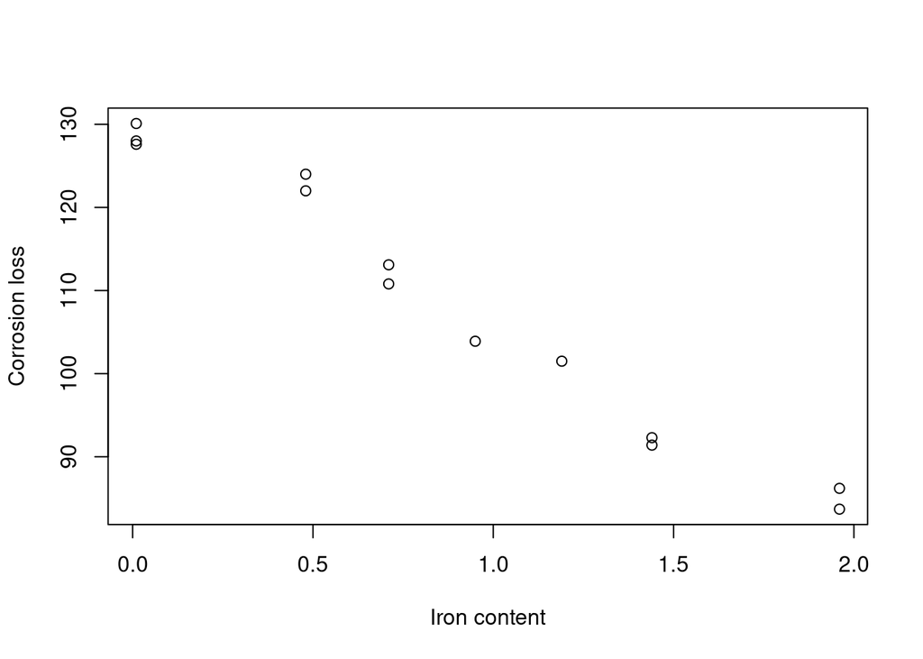

```r
alloy.dat <- read.table('datasets/alloy.dat',header = TRUE)
z         <- alloy.dat
plot(z$ironcontent,z$corrosionloss,xlab = 'Iron content', ylab = 'Corrosion loss')
```

Our goal here is to quantify the uncertainty of how changes in iron content will result in changes in corrosion loss. Consider the model, with `y` = corrosion loss, and `x` = iron content :
$$y = \beta_0 + \beta_1 x + \epsilon$$

and let $\theta = \beta_1/\beta_0$ to be our quantity of interest.

Let’s define a few things:

- `itr` : the number of bootstrap iterations, i.e., the number of samples with replacement we’ll draw from original dataset `z`.
- `theta` : variable indicating the unknown parameter $\theta$ for the regression model.
- `thetas` : a array to store parameter estimates from each bootstrap iteration.

```r
itr       = 10000
theta     = NULL
thetas    = rep(0,itr)
set.seed(0)
```

Below we’ll look at an example for bootstraping.

*Bootstrap algorithm*

1. draw bootstrap samples from $z$
2. build a regression moodel for each set of pseudo data, $z^*$
3. compute $\theta^*$ from each iteration

```r
model = lm(z[,2]~z[,1])
theta = as.numeric(model$coefficients[2]/model$coefficients[1])
for(i in 1:itr){
      z.new = z[sample(1:length(z[,1]),replace=T),]
      model = lm(z.new[,2]~z.new[,1])
      thetas[i] = model$coefficients[2]/model$coefficients[1]
}
bias = mean(thetas)-theta

## OUTPUT
print(paste('OBSERVED DATA ESTIMATE: ' ,theta))
```

```
## [1] "OBSERVED DATA ESTIMATE:  -0.185072215306193"
```

```r
print(paste('ESTIMATED BIAS: ' ,bias))
```

```
## [1] "ESTIMATED BIAS:  -0.00130179981359801"
```

```r
print(paste('BIAS-CORRECTED ESTIMATE: ' ,theta-bias  ))
```

```
## [1] "BIAS-CORRECTED ESTIMATE:  -0.183770415492595"
```

```r
ci.95 = quantile(thetas,c(0.025,0.975),na.rm=T)
```

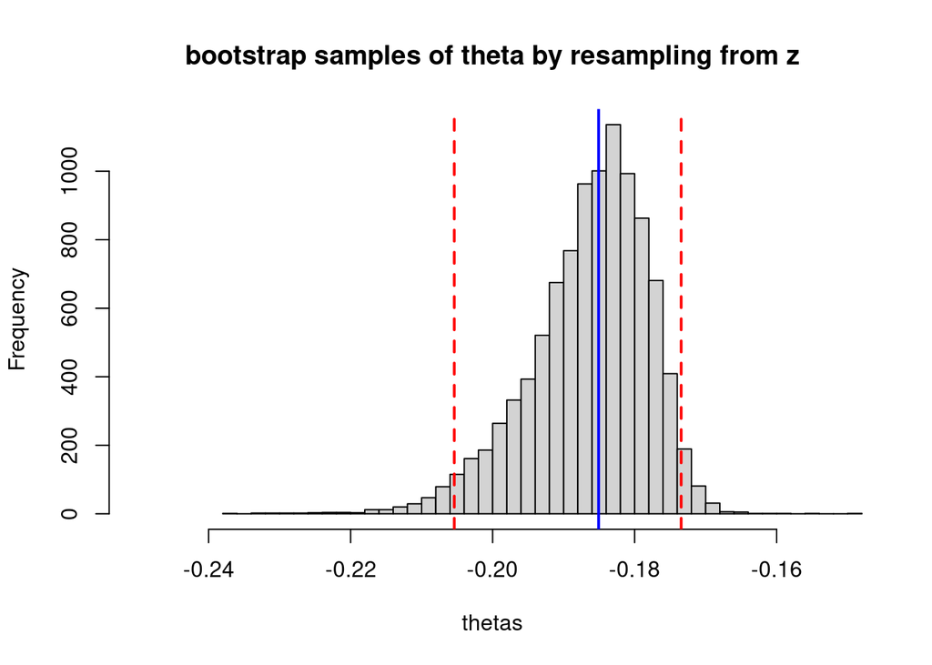

```r
## PLOTS
hist(thetas,breaks=40,
     main = 'bootstrap samples of theta by resampling from z',
     xlim = c(-0.25,-0.15))
abline(v = theta, col ='blue',lwd = 2)
abline(v = ci.95[1], col ='red',lwd = 2,lty =2)
abline(v = ci.95[2], col ='red',lwd = 2,lty =2)
```

### Bootstrap samples from residuals:

1. Start by fitting the regression model to the observed data and obtaining the fitted responses $y_i$ and residuals $\epsilon_i$.
2. Sample a bootstrap set of residuals ${\epsilon^*_1, ...,\epsilon^*_n}$ from the set of fitted residuals, completely at random with replacement.
3. Create a bootstrap set of pseudo-responses. $y^*_i = \hat{y}_i + \epsilon^*_i$
4. Regress $y^*$ on $x$ to obtain a bootstrap parameter estimate $\beta^*$
5. Repeat this process many times to build an empirical distribution for $\beta^*$ that can be used for inference.

```r
iter <-10000
model = lm(z[,2]~z[,1])
theta = as.numeric(model$coefficients[2]/model$coefficients[1])
thetas2    = rep(0,iter)
err <- residuals(model)
yhat <- fitted(model)

for(i in 1:iter){
  err.new <- err[sample(1:length(err),replace=T)]
  y.new <- yhat + err.new
  model <-lm(y.new ~ z[,1])
  thetas2[i] = model$coefficients[2]/model$coefficients[1]
  #print(thetas[i])

}

bias2 = mean(thetas2)-theta

## OUTPUT
print(paste('OBSERVED DATA ESTIMATE: ' ,theta))
```

```
## [1] "OBSERVED DATA ESTIMATE:  -0.185072215306193"
```

```r
print(paste('ESTIMATED BIAS: ' ,bias2))
```

```
## [1] "ESTIMATED BIAS:  3.42908505257811e-05"
```

```r
print(paste('BIAS-CORRECTED ESTIMATE: ' ,theta-bias2  ))
```

```
## [1] "BIAS-CORRECTED ESTIMATE:  -0.185106506156718"
```

```r
ci2.95 = quantile(thetas2,c(0.025,0.975),na.rm=T)
```

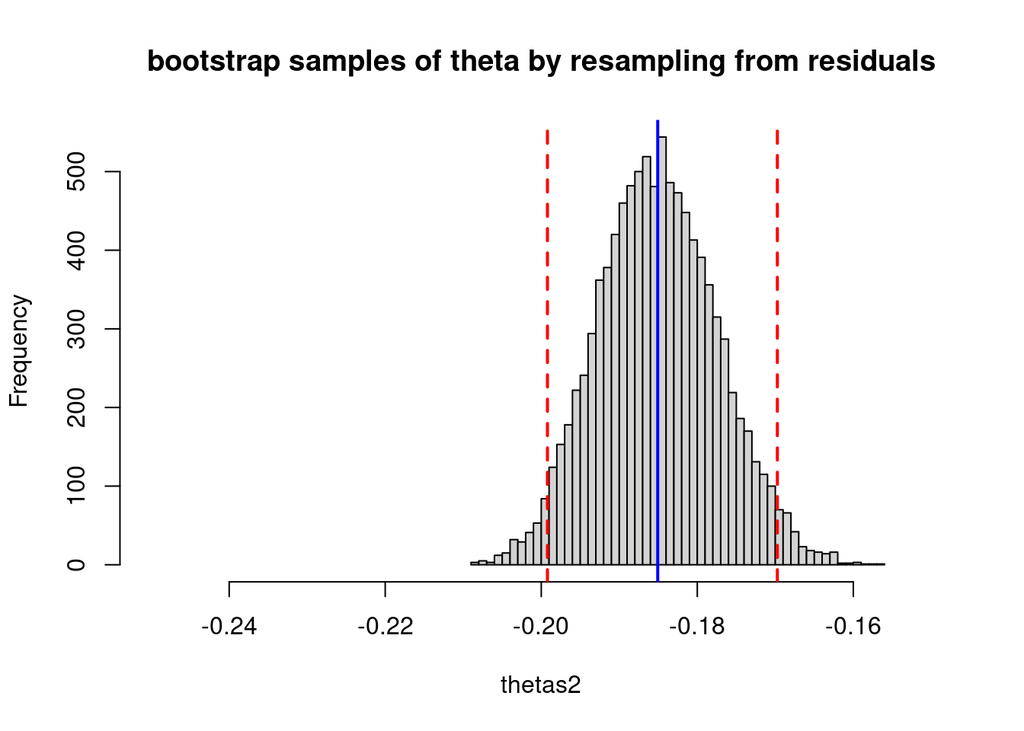

```r
## PLOTS
hist(thetas2,breaks=40,
     main = 'bootstrap samples of theta by resampling from residuals',
     xlim = c(-0.25,-0.15))
abline(v = theta, col ='blue',lwd = 2)
abline(v = ci2.95[1], col ='red',lwd = 2,lty =2)
abline(v = ci2.95[2], col ='red',lwd = 2,lty =2)
```

### Takeaway from this example

In this exercise, we compared two ways of building bootstrap estimates of a parameter derived a regression coefficients from a given data set. Below is a summary of comparison

```r
bootstrap.type <-c('Bootstrap from data', 'Bootstrap from residuals')
bias.percentage <- rbind(100*round(bias/theta,5),100*round(bias2/theta,5))
lcf <-rbind(round(ci.95[1],2),round(ci2.95[1],2))
hcf <-rbind(round(ci.95[2],2),round(ci2.95[2],2))
result.summary <- data.frame(method = bootstrap.type,bias.perc = bias.percentage, lcf = lcf,hcf = hcf)
names(result.summary) <-c('Bootstrap method','bias %', '2.5 quantile','97.5 quantile')
kableExtra::kable(result.summary)%>%
  kable_styling(htmltable_class = 'lightable-classic', bootstrap_options = 'responsive',
                position = "left", font_size = 20,full_width = FALSE)
```

| Bootstrap method | bias % | 2.5 quantile | 97.5 quantile |
| --- | --- | --- | --- |
| Bootstrap from data | 0.703 | -0.21 | -0.17 |
| Bootstrap from residuals | -0.019 | -0.20 | -0.17 |